# stats531_mid_project

## 3 Time Series Analysis

### First, plot the High price of four stocks over the time

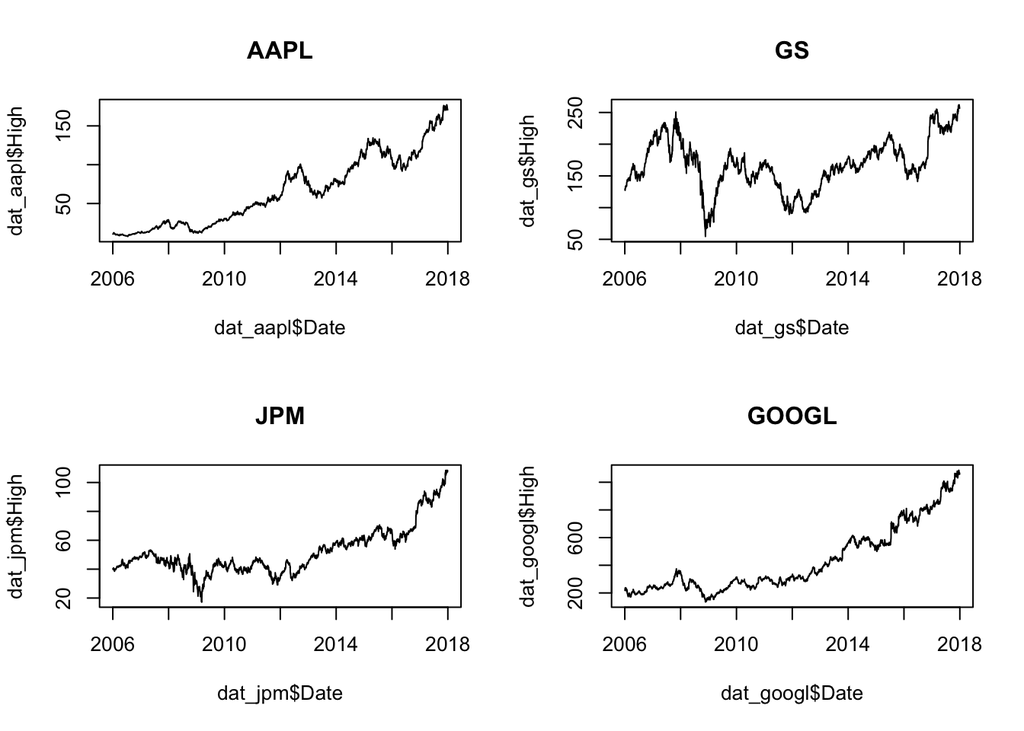

```r
par(mfrow = c(2,2))
plot(dat_aapl$High ~dat_aapl$Date,type = "l",main = "AAPL")
plot(dat_gs$High ~dat_gs$Date,type = "l",main = "GS")
plot(dat_jpm$High ~dat_jpm$Date,type = "l",main = "JPM")
plot(dat_googl$High ~dat_googl$Date,type = "l",main = "GOOGL")
```

It seems like the price of all four stocks are gradually increasing. However, it seems that GS has some fluctuation during year 2016 to 2010

### Study the ACF of the prices

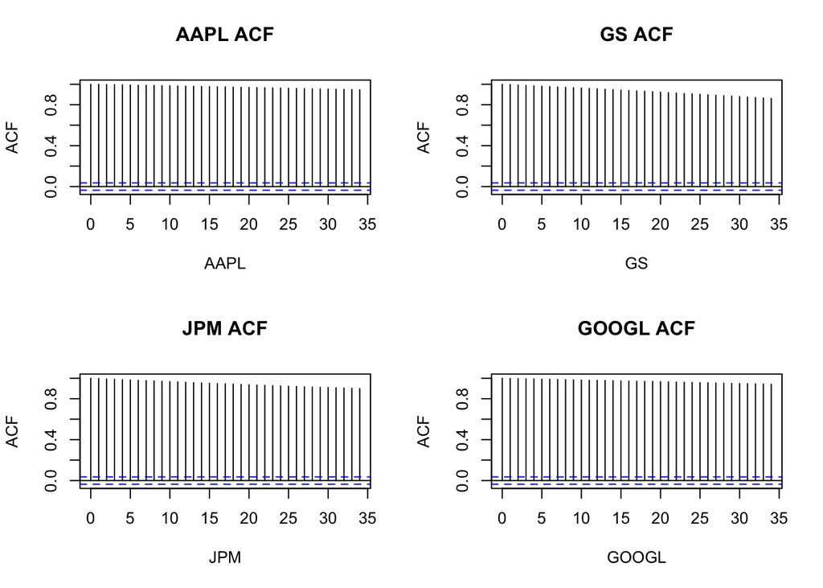

```r
par(mfrow = c(2,2))
acf(dat_aapl$High,main = "AAPL ACF",xlab = "AAPL")
acf(dat_gs$High,main = "GS ACF",xlab = "GS")
acf(dat_jpm$High,main = "JPM ACF",xlab = "JPM")
acf(dat_googl$High,main = "GOOGL ACF",xlab = "GOOGL")
```

From ACF plots, we see that the acf for all four stocks prices are highly correlated.

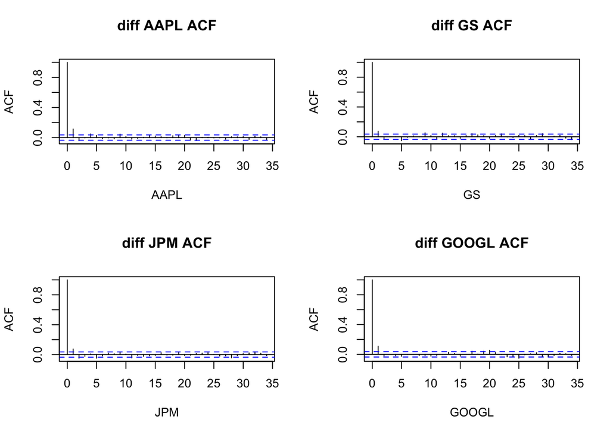

```r
par(mfrow = c(2,2))
acf(diff(dat_aapl$High),main = "diff AAPL ACF",xlab = "AAPL")
acf(diff(dat_gs$High),main = "diff GS ACF",xlab = "GS")
acf(diff(dat_jpm$High),main = "diff JPM ACF",xlab = "JPM")
acf(diff(dat_googl$High),main = "diff GOOGL ACF",xlab = "GOOGL")
```

However, the difference of the prices are not highly correlated, the only correlated lag is probably around 1 or 2.

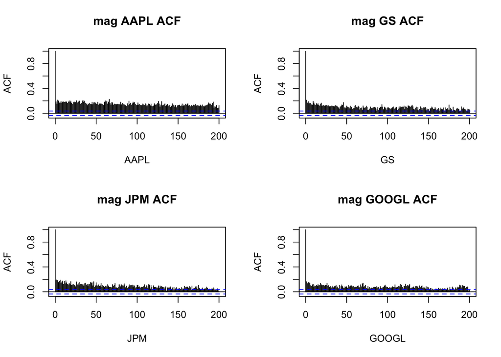

```r
par(mfrow = c(2,2))
acf(abs(diff(dat_aapl$High) - mean(diff(dat_aapl$High))),lag.max = 200,main = "mag AAPL ACF",xlab = "AAPL")
acf(abs(diff(dat_gs$High) - mean(diff(dat_gs$High))),lag.max = 200,main = "mag GS ACF",xlab = "GS")
acf(abs(diff(dat_jpm$High) - mean(diff(dat_jpm$High))),lag.max = 200,main = "mag JPM ACF",xlab = "JPM")
acf(abs(diff(dat_googl$High) - mean(diff(dat_googl$High))),lag.max = 200,main = "mag GOOGL ACF",xlab = "GOOGL")
```